# Beta diversity — filtered cohort

Anton

2026-05-31

```r
knitr::opts_knit$set(root.dir = rprojroot::find_rstudio_root_file())
knitr::opts_chunk$set(echo = TRUE, message = FALSE, warning = FALSE)
```

# Purpose

Beta diversity within the filtered Chinese cohort (`Project.ID == "PRJNA422434"`, 187 T2D + 172 Healthy). Three distance metrics are computed in parallel because each emphasises a different aspect of community structure:

| Metric | Input data | Aspect captured | Compositionally correct? |
| --- | --- | --- | --- |
| **Bray–Curtis** | Relative abundance | Abundance differences | No |
| **Jaccard** | Presence/absence | Membership (which taxa are shared) | N/A (binary) |
| **Aitchison** | CLR-transformed | Compositional log-ratio differences | **Yes** (Aitchison §7) |

For each metric we run PCoA, PERMANOVA, and `betadisper`. PERMANOVA tests whether group centroids differ; `betadisper` tests whether within-group dispersions are homogeneous. A clean centroid-shift interpretation requires significant PERMANOVA with non-significant betadisper.

**Two taught options we considered and did not use.** W20-03 also teaches **NMDS** as an ordination and the `distance()` function can compute **UniFrac** (phylogenetic). We use **PCoA** rather than NMDS because PCoA is metric (its axes preserve the actual distances, so the % variance explained is meaningful) and because it is the natural visual companion to `adonis2`, which partitions the same distance matrix — NMDS optimises rank order only and gives no variance decomposition to line up with PERMANOVA. We do **not** use UniFrac because, although both phyloseq objects carry a tree, that tree is a GTDB taxonomy cladogram whose branch lengths are almost all zero; UniFrac on near-zero branch lengths degenerates toward the unweighted membership signal we already capture with Jaccard, so it would add little beyond the three metrics above. Bray–Curtis (abundance), Jaccard (membership) and Aitchison (compositional) therefore span the informative axes for this dataset.

# 1. Libraries

```r
library(phyloseq)
library(vegan)
library(ggplot2)
library(dplyr)
library(tibble)
```

> *Taught in: W20-03 (`03_beta_diversity_and_ordination.Rmd`) §1 — phyloseq + vegan for distances/ordination; ggplot2 + tidyverse from the W20 practicals.*

# 2. Load and filter data

Load the original phyloseq objects and restrict to the Chinese cohort (`Project.ID == "PRJNA422434"`). The rationale for this filter is documented separately; in short, the other two projects in the dataset are case-only and cannot contribute to a case-control comparison.

```r
# Genus level
load("project/data/D003924_Diabetes_Mellitus,_T/genus/phyloseq.RData")
ps_genus_clean <- subset_samples(pylsq, Project.ID == "PRJNA422434")
rm(pylsq)

# Species level
load("project/data/D003924_Diabetes_Mellitus,_T/species/phyloseq.RData")
ps_species_clean <- subset_samples(pylsq, Project.ID == "PRJNA422434")
rm(pylsq)

ps_genus_clean
```

```
## phyloseq-class experiment-level object
## otu_table()   OTU Table:         [ 58 taxa and 359 samples ]
## sample_data() Sample Data:       [ 359 samples by 12 sample variables ]
## tax_table()   Taxonomy Table:    [ 58 taxa by 7 taxonomic ranks ]
## phy_tree()    Phylogenetic Tree: [ 58 tips and 27 internal nodes ]
```

```r
ps_species_clean
```

```
## phyloseq-class experiment-level object
## otu_table()   OTU Table:         [ 173 taxa and 359 samples ]
## sample_data() Sample Data:       [ 359 samples by 12 sample variables ]
## tax_table()   Taxonomy Table:    [ 173 taxa by 7 taxonomic ranks ]
## phy_tree()    Phylogenetic Tree: [ 173 tips and 59 internal nodes ]
```

> *Taught in: W20-01/W20-02 — loading the course phyloseq objects; `subset_samples()` is the phyloseq subsetting shown in W20-03. Cohort filter (PRJNA422434 only) is project-chosen, rationale in `cohort_rationale.Rmd`.*

# 3. Helper functions

```r
# Prepare phyloseq transformations
prepare_ps <- function(ps) {
  list(
    rel = transform_sample_counts(ps, function(x) x / sum(x)),
    pa  = transform_sample_counts(ps, function(x) ifelse(x > 0, 1, 0))
  )
}

# Compute Aitchison distance via vegdist (handles pseudocount + CLR internally)
aitchison_distance <- function(ps) {
  otu <- as(otu_table(ps), "matrix")
  if (taxa_are_rows(ps)) otu <- t(otu)
  vegdist(otu, method = "aitchison", pseudocount = 1)
}
```

> *Taught in: W20-03 §2 — `transform_sample_counts()` to make relative-abundance and presence/absence tables. Aitchison distance (CLR + Euclidean, with pseudocount) is from the Alberdi reading “Multivariate statistics and multiple correction” §7 (compositionality), implemented here via `vegan::vegdist(method = "aitchison")`.*

# 4. Compute all distance matrices

```r
g <- prepare_ps(ps_genus_clean)
s <- prepare_ps(ps_species_clean)

# Genus level
bray_g    <- distance(g$rel, method = "bray")
jaccard_g <- distance(g$pa,  method = "jaccard", binary = TRUE)
aitch_g   <- aitchison_distance(ps_genus_clean)

# Species level
bray_s    <- distance(s$rel, method = "bray")
jaccard_s <- distance(s$pa,  method = "jaccard", binary = TRUE)
aitch_s   <- aitchison_distance(ps_species_clean)
```

> *Taught in: W20-03 §2 — `distance()` / `phyloseq::distance()` for Bray–Curtis and Jaccard (binary). Aitchison as above (Alberdi reading §7).*

# 5. PCoA — all three metrics, both levels

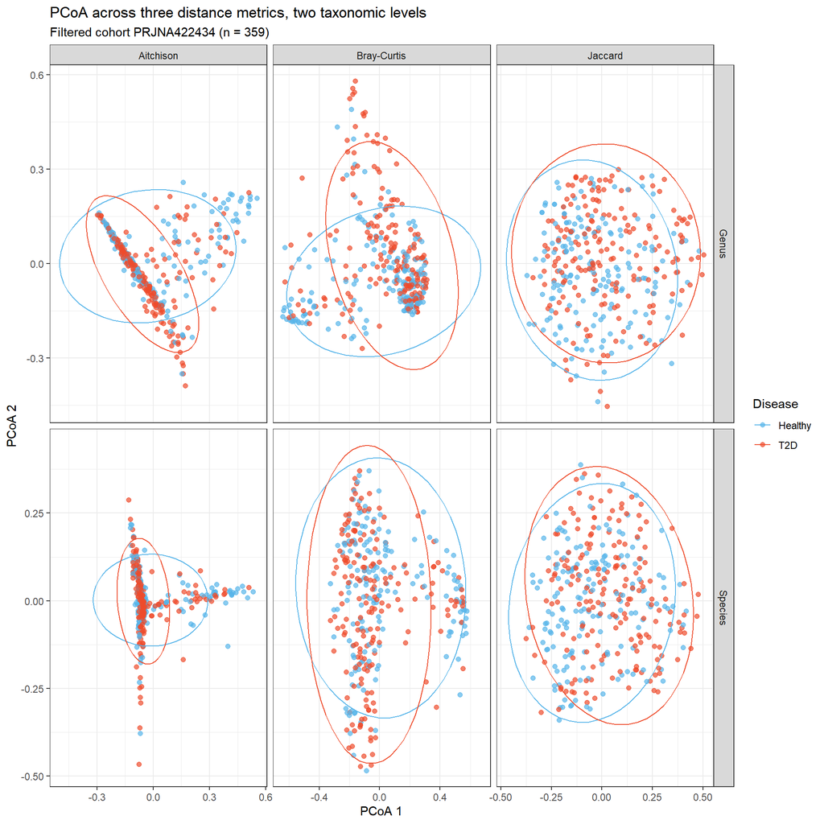

```r
make_ord_df <- function(ps_for_plot, dist_obj, metric_label, level_label) {
  ord <- ordinate(ps_for_plot, method = "PCoA", distance = dist_obj)
  eig <- ord$values$Relative_eig
  df  <- plot_ordination(ps_for_plot, ord, type = "samples", justDF = TRUE) |>
    mutate(metric = metric_label,
           level  = level_label,
           ax1_pct = round(100 * eig[1], 1),
           ax2_pct = round(100 * eig[2], 1))
  df
}

ord_dfs <- bind_rows(
  make_ord_df(g$rel, bray_g,    "Bray-Curtis", "Genus"),
  make_ord_df(g$pa,  jaccard_g, "Jaccard",     "Genus"),
  make_ord_df(ps_genus_clean, aitch_g, "Aitchison", "Genus"),
  make_ord_df(s$rel, bray_s,    "Bray-Curtis", "Species"),
  make_ord_df(s$pa,  jaccard_s, "Jaccard",     "Species"),
  make_ord_df(ps_species_clean, aitch_s, "Aitchison", "Species")
) |>
  mutate(Disease = ifelse(Disease.MESH.ID == "D003924", "T2D", "Healthy"))

ggplot(ord_dfs, aes(x = Axis.1, y = Axis.2, color = Disease)) +
  geom_point(size = 1.8, alpha = 0.7) +
  stat_ellipse(level = 0.95) +
  facet_grid(level ~ metric, scales = "free") +
  scale_color_manual(values = c("Healthy" = "#56B4E9", "T2D" = "#EE4B2B")) +
  theme_bw() +
  labs(title = "PCoA across three distance metrics, two taxonomic levels",
       subtitle = "Filtered cohort PRJNA422434 (n = 359)",
       x = "PCoA 1", y = "PCoA 2")
```

> *Taught in: W20-03 §3 — `ordinate(method = "PCoA")` and `plot_ordination()`; faceting / 95% ellipses are standard ggplot presentation of the same ordination.*

# 6. PERMANOVA — all six combinations

```r
run_permanova <- function(dist_obj, sample_df, level_label, metric_label) {
  ad <- adonis2(dist_obj ~ Disease.MESH.ID, data = sample_df, permutations = 999)
  tibble(
    level   = level_label,
    metric  = metric_label,
    F_stat  = round(ad$F[1], 2),
    R2      = round(ad$R2[1], 4),
    p_value = ad$`Pr(>F)`[1]
  )
}

sample_df_g <- sample_data(ps_genus_clean)   |> data.frame()
sample_df_s <- sample_data(ps_species_clean) |> data.frame()

permanova_results <- bind_rows(
  run_permanova(bray_g,    sample_df_g, "Genus",   "Bray-Curtis"),
  run_permanova(jaccard_g, sample_df_g, "Genus",   "Jaccard"),
  run_permanova(aitch_g,   sample_df_g, "Genus",   "Aitchison"),
  run_permanova(bray_s,    sample_df_s, "Species", "Bray-Curtis"),
  run_permanova(jaccard_s, sample_df_s, "Species", "Jaccard"),
  run_permanova(aitch_s,   sample_df_s, "Species", "Aitchison")
)

permanova_results
```

```
## # A tibble: 6 × 5
##   level   metric      F_stat     R2 p_value
##   <chr>   <chr>        <dbl>  <dbl>   <dbl>
## 1 Genus   Bray-Curtis   6.78 0.0186   0.001
## 2 Genus   Jaccard       4.73 0.0131   0.001
## 3 Genus   Aitchison     6.14 0.0169   0.002
## 4 Species Bray-Curtis   4.13 0.0114   0.001
## 5 Species Jaccard       3.34 0.0093   0.001
## 6 Species Aitchison     4.5  0.0124   0.001
```

> *Taught in: W20-03 §4 — `vegan::adonis2()` PERMANOVA testing group differences in community composition (Alberdi reading §8, whole-community structure).*

# 7. betadisper — dispersion check for each PERMANOVA

```r
run_betadisper <- function(dist_obj, grouping, level_label, metric_label) {
  disp <- betadisper(dist_obj, grouping)
  aov_out <- anova(disp)
  tibble(
    level   = level_label,
    metric  = metric_label,
    F_stat  = round(aov_out$`F value`[1], 2),
    p_value = aov_out$`Pr(>F)`[1]
  )
}

betadisper_results <- bind_rows(
  run_betadisper(bray_g,    sample_df_g$Disease.MESH.ID, "Genus",   "Bray-Curtis"),
  run_betadisper(jaccard_g, sample_df_g$Disease.MESH.ID, "Genus",   "Jaccard"),
  run_betadisper(aitch_g,   sample_df_g$Disease.MESH.ID, "Genus",   "Aitchison"),
  run_betadisper(bray_s,    sample_df_s$Disease.MESH.ID, "Species", "Bray-Curtis"),
  run_betadisper(jaccard_s, sample_df_s$Disease.MESH.ID, "Species", "Jaccard"),
  run_betadisper(aitch_s,   sample_df_s$Disease.MESH.ID, "Species", "Aitchison")
)

betadisper_results
```

```
## # A tibble: 6 × 4
##   level   metric      F_stat   p_value
##   <chr>   <chr>        <dbl>     <dbl>
## 1 Genus   Bray-Curtis   1.41 0.236
## 2 Genus   Jaccard      16.1  0.0000741
## 3 Genus   Aitchison     0.41 0.522
## 4 Species Bray-Curtis   7.9  0.00522
## 5 Species Jaccard      12.4  0.000492
## 6 Species Aitchison     4.46 0.0354
```

> *Taught in: W20-03 §4 — `vegan::betadisper()` + `anova()` to test homogeneity of within-group dispersion, the standard companion check to PERMANOVA.*

# 8. Joint summary table

```r
beta_summary <- permanova_results |>
  rename(perm_F = F_stat, perm_p = p_value) |>
  left_join(
    betadisper_results |>
      rename(disp_F = F_stat, disp_p = p_value),
    by = c("level", "metric")
  ) |>
  mutate(
    perm_p_label = ifelse(perm_p < 0.001, "< 0.001", signif(perm_p, 3)),
    disp_p_label = ifelse(disp_p < 0.001, "< 0.001", signif(disp_p, 3)),
    cleanly_interpretable = perm_p < 0.05 & disp_p > 0.05
  )

beta_summary
```

```
## # A tibble: 6 × 10
##   level   metric   perm_F     R2 perm_p disp_F  disp_p perm_p_label disp_p_label
##   <chr>   <chr>     <dbl>  <dbl>  <dbl>  <dbl>   <dbl>        <dbl> <chr>
## 1 Genus   Bray-Cu…   6.78 0.0186  0.001   1.41 2.36e-1        0.001 0.236
## 2 Genus   Jaccard    4.73 0.0131  0.001  16.1  7.41e-5        0.001 < 0.001
## 3 Genus   Aitchis…   6.14 0.0169  0.002   0.41 5.22e-1        0.002 0.522
## 4 Species Bray-Cu…   4.13 0.0114  0.001   7.9  5.22e-3        0.001 0.00522
## 5 Species Jaccard    3.34 0.0093  0.001  12.4  4.92e-4        0.001 < 0.001
## 6 Species Aitchis…   4.5  0.0124  0.001   4.46 3.54e-2        0.001 0.0354
## # ℹ 1 more variable: cleanly_interpretable <lgl>
```

> *Taught in: project synthesis — joins the PERMANOVA and betadisper results (both W20-03 §4) into one table; the `cleanly_interpretable` flag is our reading rule, not a separate method.*

The `cleanly_interpretable` column flags rows where a significant PERMANOVA result can be interpreted as a true centroid shift (significant PERMANOVA AND non-significant betadisper).

# 9. Covariate-adjusted PERMANOVA

Within the filtered cohort, residual confounders (BMI, age, sex) may still partly explain community variation. The marginal PERMANOVA partitions variance between each predictor adjusted for the others.

```r
adjusted_df_g <- sample_df_g |>
  filter(!is.na(BMI), !is.na(Host.age), !is.na(Sex))

# Re-subset distance matrix to match
keep_g <- sample_df_g$Run.ID %in% adjusted_df_g$Run.ID
bray_g_keep <- as.matrix(bray_g)[keep_g, keep_g] |> as.dist()

adonis2(bray_g_keep ~ Disease.MESH.ID + BMI + Host.age + Sex,
        data = adjusted_df_g,
        by = "margin",
        permutations = 999)
```

```
## Permutation test for adonis under reduced model
## Marginal effects of terms
## Permutation: free
## Number of permutations: 999
##
## adonis2(formula = bray_g_keep ~ Disease.MESH.ID + BMI + Host.age + Sex, data = adjusted_df_g, permutations = 999, by = "margin")
##                  Df SumOfSqs      R2      F Pr(>F)
## Disease.MESH.ID   1   0.2300 0.00828 1.2732  0.248
## BMI               1   0.1793 0.00646 0.9926  0.433
## Host.age          1   0.1960 0.00706 1.0850  0.347
## Sex               1   0.2483 0.00894 1.3741  0.196
## Residual        146  26.3774 0.94975
## Total           150  27.7731 1.00000
```

> *Taught in: W20-03 §4 (`adonis2` PERMANOVA) extended with covariates per W21 reference Rmd §7 / Alberdi reading §5. The multi-term marginal model (`by = "margin"`) and the choice of BMI / host age / sex are project-chosen; the underlying method (adonis2 with adjustment) is taught.*

```r
aitch_g_keep <- as.matrix(aitch_g)[keep_g, keep_g] |> as.dist()

adonis2(aitch_g_keep ~ Disease.MESH.ID + BMI + Host.age + Sex,
        data = adjusted_df_g,
        by = "margin",
        permutations = 999)
```

```
## Permutation test for adonis under reduced model
## Marginal effects of terms
## Permutation: free
## Number of permutations: 999
##
## adonis2(formula = aitch_g_keep ~ Disease.MESH.ID + BMI + Host.age + Sex, data = adjusted_df_g, permutations = 999, by = "margin")
##                  Df SumOfSqs      R2      F Pr(>F)
## Disease.MESH.ID   1   0.0962 0.00791 1.2177  0.256
## BMI               1   0.1058 0.00871 1.3402  0.199
## Host.age          1   0.0905 0.00745 1.1464  0.283
## Sex               1   0.1223 0.01006 1.5484  0.166
## Residual        146  11.5307 0.94866
## Total           150  12.1548 1.00000
```

> *Taught in: same as above (adonis2, W20-03 §4 + covariate adjustment W21 §7) applied to the Aitchison distance (Alberdi reading §7), giving a compositionally-correct covariate-adjusted test.*

Aitchison adjusted is the most defensible single test — compositionally correct AND covariate adjusted. If `Disease.MESH.ID` is significant in this model, the disease effect on community composition survives adjustment for BMI, age, and sex within the cohort.

# 10. Interpretation guide

Reading the joint summary:

- **All three metrics significant in PERMANOVA** ⇒ robust disease effect across abundance-based, presence/absence, and compositional perspectives.
- **Aitchison `cleanly_interpretable = TRUE`** ⇒ the compositionally-rigorous metric gives a clean centroid-shift interpretation.
- **Disagreement between genus and species** ⇒ informative; the level at which the signal appears tells you about the resolution of the disease effect.
- **R² values** ⇒ typically 1–5% for disease in human gut microbiome studies; report alongside p-values to avoid over-claiming statistical significance for small effects.

For the report, the cleanest single sentence is: *“PERMANOVA on Aitchison distance, adjusted for BMI, host age, and sex, partitioned X% of community variance to disease state (p = Y) with no dispersion confound (betadisper p = Z).”*

# 11. Save outputs

```r
#saveRDS(list(bray = bray_g, jaccard = jaccard_g, aitchison = aitch_g),
#        "project/results/beta_distances_genus.rds")

#saveRDS(list(bray = bray_s, jaccard = jaccard_s, aitchison = aitch_s),
#        "project/results/beta_distances_species.rds")

#saveRDS(beta_summary, "project/results/beta_diversity_summary.rds")
```

> *Taught in: housekeeping (`saveRDS`) — not a course method; persists distance matrices and the summary for reuse.*